# HW 1: dpodolin-report

Подолин Дмитрий, dpodolin

## Задача

на основе данных (и выданных вопросов) постараться выяснить:

- какие проблемы есть в авиаперевозках
- какие улучшения можно предложить на основе выводов по данным

#### Загрузка данных и преобразование

```r
library(dplyr)
library(ggplot2)
library(lubridate)
library(stringr)

source("~/shared/minor2_2023/1-Intro/hw1/hw1_data.R")

airline = hw1_get_data(df_name = "airline")
airport = hw1_get_data(df_name = "airport")
lounge = hw1_get_data(df_name = "lounge")
seat = hw1_get_data(df_name = "seat")

hw1_get_questions()
```

| id | questions |
| --- | --- |
| 1 | -Правда ли оценка ширины кресла (seat_width) выше, если перелет был в летнее время? |
| 2 | -В каких самолетах более высокие оценки удобства пространства для ног — те, в которых два прохода или один? |
| 3 | -Какие лаунж-зоны оценены по чистоте (cleanliness) выше, чем аэропорты, в которых они расположены? |

Мы преобразовали все даты в дата сете seat в формат дат; В сете seat в столбце seat_layout, описывающий количество проходов, мы преобразовали два значения в формат всех остальных.

```r
seat$date = ymd(seat$date)
seat$date_flown = dmy(seat$date_flown)
seat[23, 9] = "3x3"
seat[92, 9] = "3x3"


# преобразование данных, предобработка
```

### Вопросы

#### Вопрос 1

**Вопрос:** -Правда ли оценка ширины кресла (seat_width) выше, если перелет был в летнее время?

**Данные:** для ответа на вопрос нужны таблицы seat.

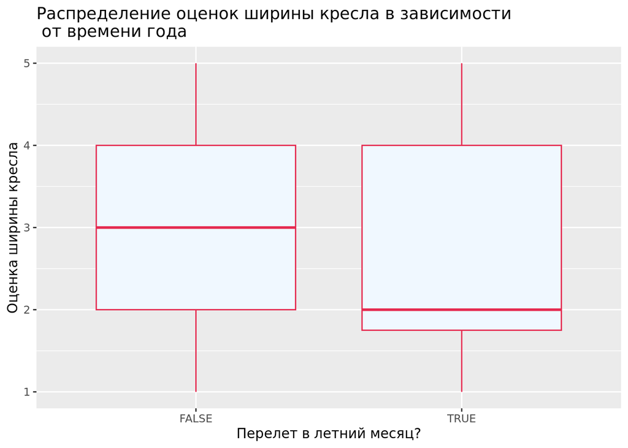

```r
seat_with_summ = seat %>% mutate(summ = (month(date_flown) %in% c(6,7,8)))
ggplot() +
  geom_boxplot(data = seat_with_summ, aes(x = factor(summ), y = seat_width_rating), col = "#E52B50", fill = "#F0F8FF") +
  xlab("Перелет в летний месяц?") +
  ylab("Оценка ширины кресла") +
  ggtitle("Распределение оценок ширины кресла в зависимости\n от времени года")
```

```r
mean_for_summ = seat_with_summ %>% filter(summ)
a = mean(mean_for_summ$seat_width_rating)
cat(a," средняя арифметическая оценка летом \n")
```

```
## 2.625  средняя арифметическая оценка летом
```

```r
mean_for_notsumm = seat_with_summ %>% filter(summ == F)
b = mean(mean_for_notsumm$seat_width_rating)
cat(b," средняя арифметическая оценка не летом")
```

```
## 2.814286  средняя арифметическая оценка не летом
```

**Ответ:** Нет, в летние месяцы оценка ширины кресел ниже, чем в другие месяцы.

**Вывод:** На основе исследования оценки ширины кресел в зависимости от времени года, видно, что и среднее арифметическое, и медианное значение оценки летом ниже, чем не летом. Кроме того, из анализа при помощи ящика с усами следует, что летом половина людей ставит оценку 2 и ниже, а в иное время года половина пассажиров за 3 и ниже, другая же половина, за 3 и выше. То есть летом недовольных качеством ширины сидения больше. Нужно прислушатся к отзывам о ширирне кресел в летнее время и попытаться скрыть этот недостаток. Необходимо либо фактически изменить сидения, либо посмотреть корреляцию оценки некоторого иного признака с оценкой ширины сидения, и влиять на оценку ширины при помощи изменения этого признака. Кроме того, внимания заслуживает факт, что в общем и целом оценки в обоих случаях достаточно низкие, т.е. нужно пытаться изменить и улучшить кресла.

#### Вопрос 2

**Вопрос:** -В каких самолетах более высокие оценки удобства пространства для ног — те, в которых два прохода или один?

**Данные:** для ответа на вопрос нужны таблицы seat.

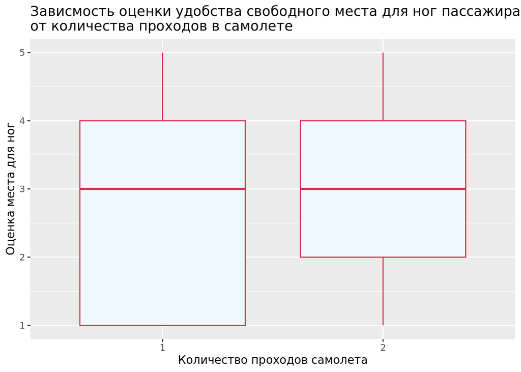

```r
seat_with_prohod = seat %>% filter(seat_layout != "Deck")
seat_with_prohod = seat_with_prohod %>% mutate(prohodi = str_count(seat_with_prohod$seat_layout,"x"))

ggplot() +
  geom_boxplot(data = seat_with_prohod, aes(x = factor(prohodi), y = seat_legroom_rating), col = "#E52B50", fill = "#F0F8FF") +
  xlab("Количество проходов самолета") +
  ylab("Оценка места для ног") +
  ggtitle("Зависмость оценки удобства свободного места для ног пассажира \nот количества проходов в самолете")
```

```r
mean_for_1 = seat_with_prohod %>% filter(prohodi == 1)
a = mean(mean_for_1$seat_legroom_rating)
cat(a," средняя арифметическая оценка c 1 проходом \n")
```

```
## 2.814815  средняя арифметическая оценка c 1 проходом
```

```r
mean_for_2 = seat_with_prohod %>% filter(prohodi == 2)
b = mean(mean_for_2$seat_legroom_rating)
cat(b," средняя оценка арифметическая с 2 проходами")
```

```
## 2.991667  средняя оценка арифметическая с 2 проходами
```

**Ответ:** Более удобная оценка пространства для ног в самолетах с двумя рядами.

#### Вопрос 3

**Вопрос:** -Какие лаунж-зоны оценены по чистоте (cleanliness) выше, чем аэропорты, в которых они расположены?

**Данные:** для ответа на вопрос нужны таблицы lounge, airport.

[figure not shown]

```r
loun = lounge %>% select(title = airport, cleanliness_rating,lounge_name)
loun$lounge_name = str_remove_all(loun$lounge_name, " LOUNGE REVIEW")
loun$lounge_name = str_remove_all(loun$lounge_name, " CUSTOMER REVIEW")

airp = airport %>% select(title, terminal_cleanliness_rating)
airp$title = str_remove_all(airp$title, " customer review")
airp$title = str_remove_all(airp$title, " CUSTOMER REVIEW")


vmeste = inner_join(loun, airp)  %>% filter(!is.na(terminal_cleanliness_rating))%>% filter(!is.na(cleanliness_rating))  %>% group_by(lounge_name) %>% summarise(mean_terminal_cleanliness_rating=mean(terminal_cleanliness_rating), mean_lounge_cleanliness_rating = mean(cleanliness_rating)) %>% filter(mean_lounge_cleanliness_rating>mean_terminal_cleanliness_rating)

otv = left_join(vmeste, select(loun, title, lounge_name)) %>% distinct(.keep_all = TRUE ) %>% mutate(raznitsa =mean_lounge_cleanliness_rating - mean_terminal_cleanliness_rating )
otv$full = paste(otv$title, otv$lounge_name, sep=" \n")




q = top_n(otv,5,otv$raznitsa) %>% arrange(-raznitsa) #смотрим полезную информацию - топ 5 аэропортов с большей разницей двух оценок, из otv - переменная q


ggplot()+
  geom_bar(data = q, aes(x = full, width = 0.8, y =mean_lounge_cleanliness_rating), stat = "identity", col = "#403a3a", fill = "pink") +
  geom_bar(data = q, aes(x = full,width = 0.6, y = mean_terminal_cleanliness_rating), stat = "identity", col = "grey", fill = "#9224A6", alpha = 0.5)+
  theme(axis.text.y = element_text(angle =30,size = 6))+
  xlab("Назавние аэропорта и лаунж зоны") +
  ylab("Оценка чистоты аэропорта(пурпурный) \n Оценка чистоы лаунж зоны(розовый)") +
  ggtitle("Топ 5 аэропортов с наибольшей \n разницей чистоты,\n удовлетворяющих условию")+
  coord_flip()
```

### Дэшборд

Полученные выводы обобщены в виде дэшборда со следующими элементами

**Элемент 1:** - вид: график ящик с усами - ответ на вопрос: 1 - обоснование: кроме иллюстрации явной тенденции, на графике виден еще и факт впринципе низких оценок не только летом, но и в иное время года

**Элемент 2:** - вид: число - ответ на вопрос: 2 - обоснование: хочу напрямую ответить на вопрос в каком типе самолета(по количеству проходов) ставят оценки удобству места для ног выше, то есть где люди довольнее предоставляемым местом для ног

**Элемент 4:** - вид: график бар чат - ответ на вопрос: 3 - обоснование: показывает аэропорты-лаунж зоны с наиболее инетересной зависимостью среди удовлетворяющих условию

### Общие выводы

Анализ данных, проведенный в этой работе позволили выявить недостатки и слабые стороны, некоторых аэропортов, самолетов с разными конкретными характеритиками, а также установить зависимоть комфорта перелета и времени года, когда происходил перелет. Уже даже на основе данного, небольшого по объему исследования, возможно сделать выводы и перейти к решению проблем. Конечно, более детальный анализ позволит выявить и устранить недостатки гораздо эффективнее, но даже сейчас на лицо явный результат. Мне понравилась данная работа, в будущем буду раз проводить подобные или более детальные исследования.